# Clustering

Biostatistics 735/794 — Machine Learning in Public Health

Author

Alexander McLain

Published

October 6, 2026

# 1 Introduction

This example explores several clustering techniques—K-means, PAM, Gaussian Mixture Models (GMM), and Hierarchical Clustering—applied to the NCI60 gene expression dataset. We also cluster the **t-SNE and UMAP scores** (clustering in a low-dimensional embedding rather than in the original 6,830 genes), and we choose the number of clusters using Elbow, Gap Statistic, and silhouette methods.

We **compare all of the methods** using internal validation (do the clusters look good?), external validation (do they match the known cancer types?), and stability (do we get the same answer if we change the random seed?).

# 2 Load and Prepare the Data

The data are a NCI microarray dataset. The data contains expression levels on 6830 genes from 64 cancer cell lines. Cancer type is also recorded.

```r
data("NCI60")
X <- NCI60$data
dim(X)
```

```
[1]   64 6830
```

```r
# Standardize features
X.scaled <- scale(X)
```

## 2.1 Choosing the Number of Clusters

### 2.1.1 Elbow Method

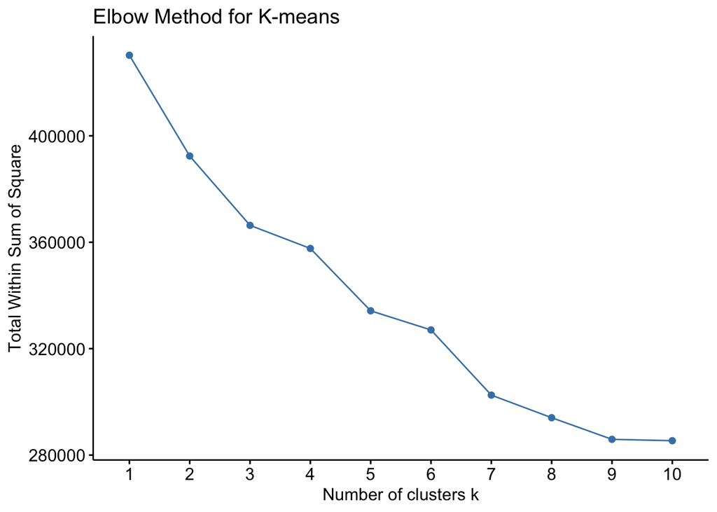

```r
fviz_nbclust(X.scaled, kmeans, method = "wss") +
  labs(title = "Elbow Method for K-means")
```

### 2.1.2 Gap Statistic

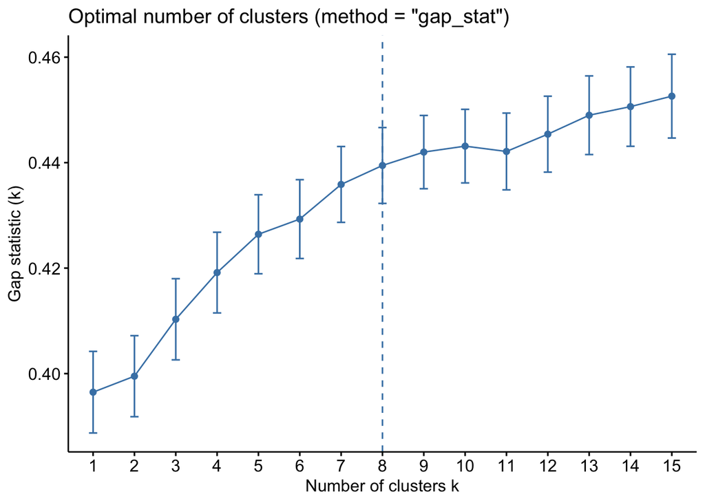

```r
set.seed(123)
gap_kmeans <- clusGap(X.scaled, FUN = kmeans, nstart = 25, K.max = 15, B = 50)
fviz_gap_stat(gap_kmeans)
```

One widely used criterion is to use the smallest $k$ such that $f(k) \geq f(k+1) - s_{k+1}$.

# 3 K-means Clustering

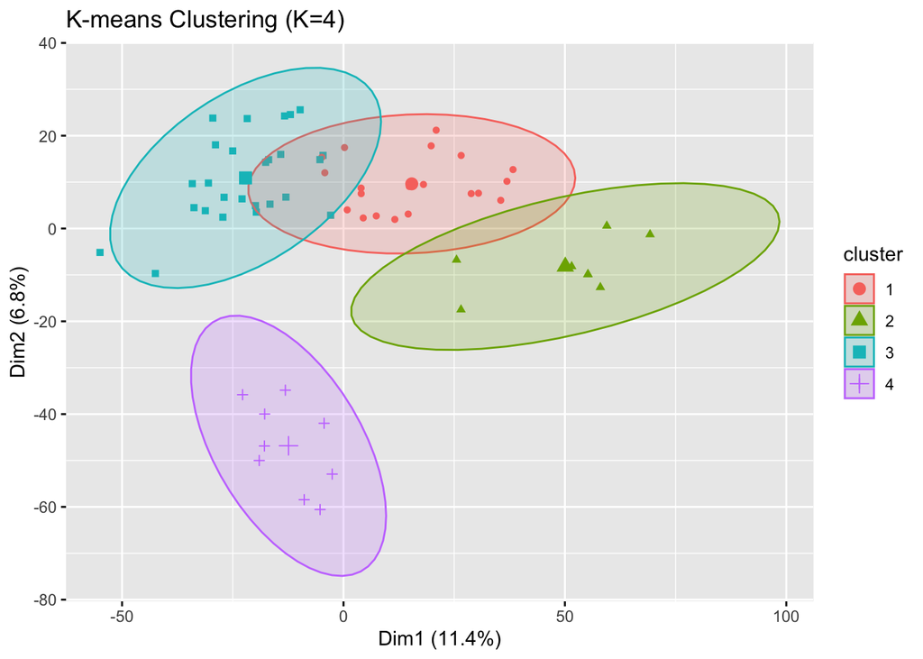

```r
set.seed(123)
km_res <- kmeans(X.scaled, centers = 4, nstart = 25)
fviz_cluster(km_res, data = X.scaled, geom = "point", ellipse.type = "norm") +
  labs(title = "K-means Clustering (K=4)")
```

```r
table(NCI60$labs, km_res$cluster)
```

```
              1 2 3 4
  BREAST      2 0 3 2
  CNS         0 0 5 0
  COLON       7 0 0 0
  K562A-repro 0 1 0 0
  K562B-repro 0 1 0 0
  LEUKEMIA    0 6 0 0
  MCF7A-repro 1 0 0 0
  MCF7D-repro 1 0 0 0
  MELANOMA    0 0 1 7
  NSCLC       5 0 4 0
  OVARIAN     3 0 3 0
  PROSTATE    1 0 1 0
  RENAL       0 0 9 0
  UNKNOWN     0 0 1 0
```

# 4 Silhouette Width

For each observation i, the silhouette width measures how well it fits within its assigned cluster compared to other clusters. It’s defined as:

$$s(i) = \frac{b(i) - a(i)}{\max\{a(i), b(i)\}}$$

where:

• $a(i)$: the average distance from $i$ to all other points in its own cluster (cohesion).

• $b(i)$: the lowest average distance from $i$ to all points in another cluster (separation).

## 4.1 Average Silhouette Width

The average silhouette width across all observations gives an overall summary of clustering quality:

$$S = \frac{1}{n} \sum_{i=1}^n s(i)$$

• $S$ ranges between $-1$ and $+1$.

• Higher $S$ means better-defined and more separated clusters.

• When comparing cluster solutions with different $K$ values, choose the $K$ that maximizes $S$.

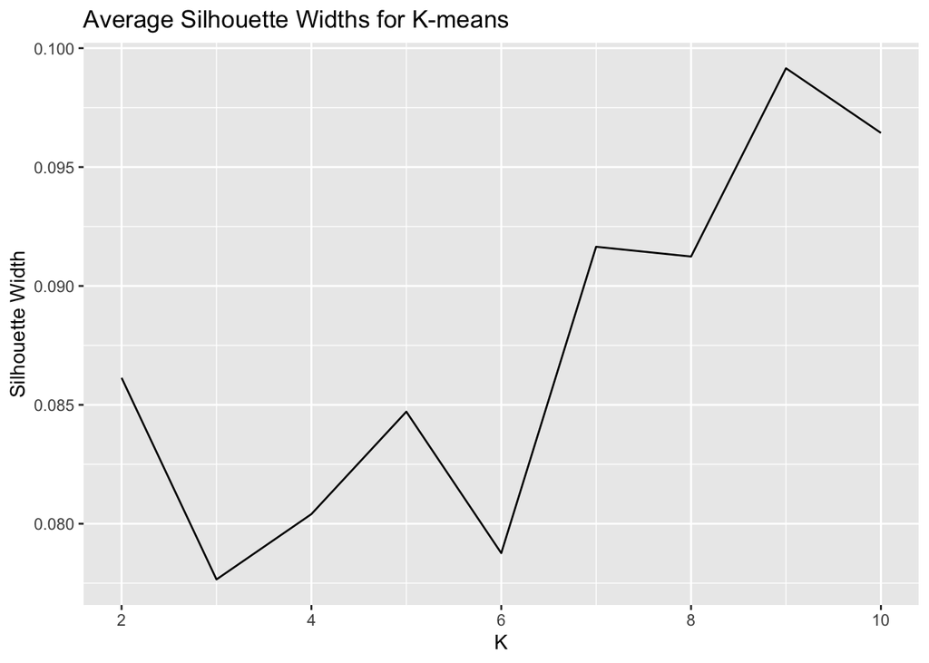

```r
sil_widths <- sapply(2:10, function(k){
  km <- kmeans(X.scaled, centers = k, nstart = 25)
  mean(silhouette(km$cluster, dist(X.scaled))[, 3])
})
qplot(2:10, sil_widths, geom="line") +
  labs(title="Average Silhouette Widths for K-means", x="K", y="Silhouette Width")
```

```
  cluster size ave.sil.width
1       1    5          0.01
2       2    4          0.29
3       3    8          0.09
4       4    3          0.49
5       5   10          0.04
6       6   21          0.04
7       7    4          0.00
8       8    9          0.16
```

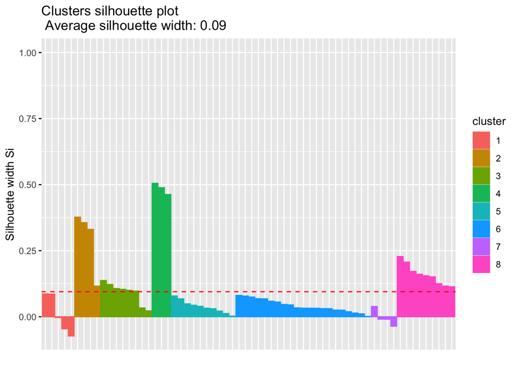

```r
set.seed(123)
km_res8 <- kmeans(X.scaled, centers = 8, nstart = 25)
fviz_silhouette(silhouette(km_res8$cluster, dist(X.scaled)))
```

```
  cluster size ave.sil.width
1       1   20          0.07
2       2    8          0.10
3       3   27          0.05
4       4    9          0.17
```

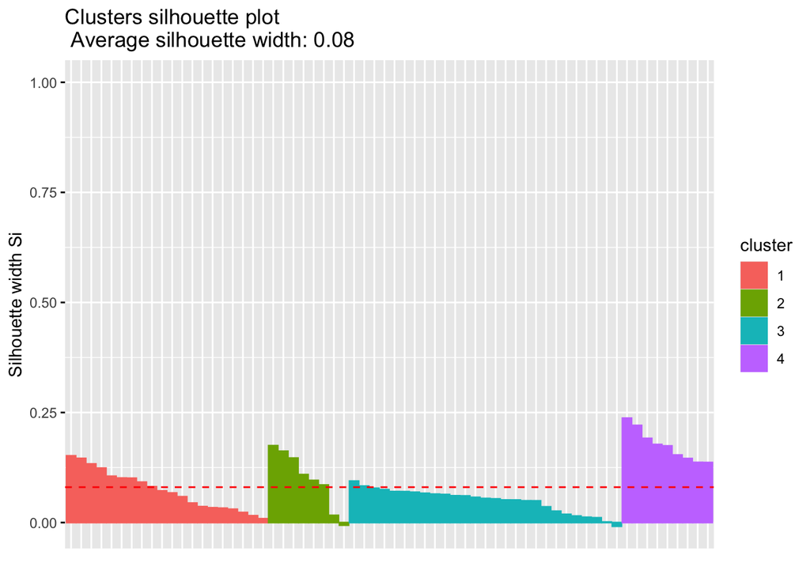

```r
fviz_silhouette(silhouette(km_res$cluster, dist(X.scaled)))
```

# 5 Partitioning Around Medoids (PAM)

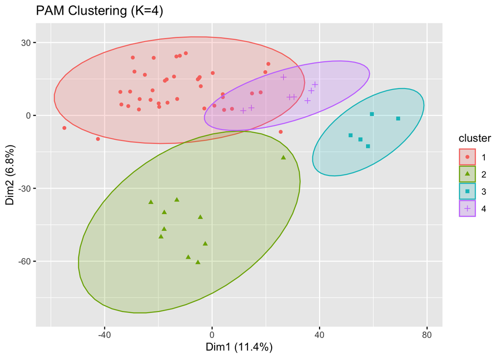

```r
pam_res <- pam(X.scaled, k = 4, metric = "euclidean")
fviz_cluster(pam_res, data = X.scaled, geom = "point", ellipse.type = "norm") +
  labs(title = "PAM Clustering (K=4)")
```

```r
table(NCI60$labs, pam_res$clustering)
```

```
              1 2 3 4
  BREAST      3 2 0 2
  CNS         5 0 0 0
  COLON       4 0 0 3
  K562A-repro 0 0 1 0
  K562B-repro 0 0 1 0
  LEUKEMIA    1 1 4 0
  MCF7A-repro 0 0 0 1
  MCF7D-repro 0 0 0 1
  MELANOMA    1 7 0 0
  NSCLC       8 0 0 1
  OVARIAN     6 0 0 0
  PROSTATE    2 0 0 0
  RENAL       9 0 0 0
  UNKNOWN     1 0 0 0
```

```
  cluster size ave.sil.width
1       1   40          0.05
2       2   10          0.14
3       3    6          0.18
4       4    8          0.10
```

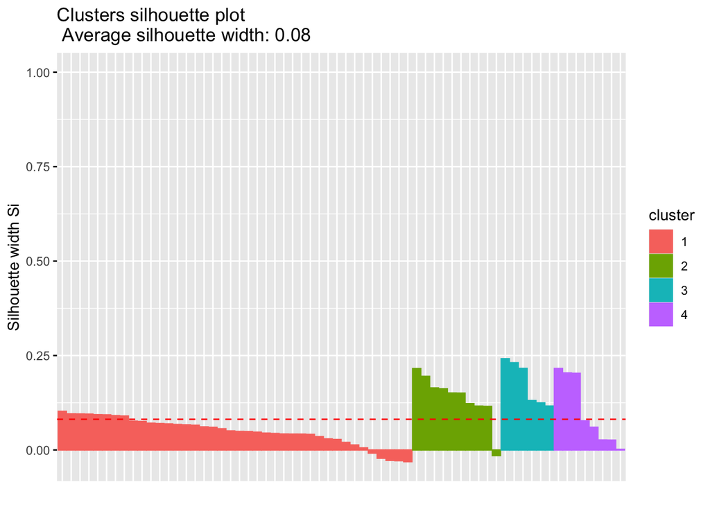

```r
fviz_silhouette(pam_res)
```

# 6 Gaussian Mixture Model (Model-based Clustering)

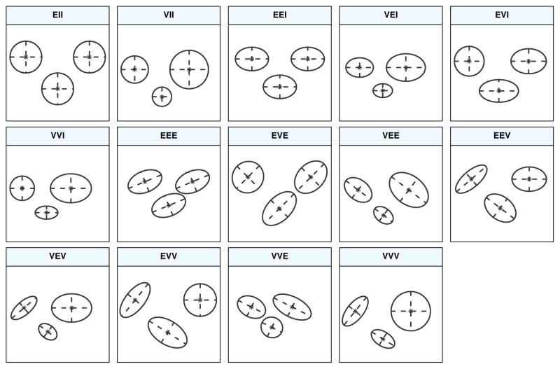

Ellipses of isodensity for each of the 14 Gaussian models obtained by eigen-decomposition in case of three groups in two dimensions.

```r
gmm_res <- Mclust(X.scaled, G = 1:10)
summary(gmm_res)
```

```
----------------------------------------------------
Gaussian finite mixture model fitted by EM algorithm
----------------------------------------------------

Mclust VII (spherical, varying volume) model with 3 components:

 log-likelihood  n    df      BIC      ICL
      -580289.8 64 20495 -1245816 -1245816

Clustering table:
 1  2  3
35 20  9
```

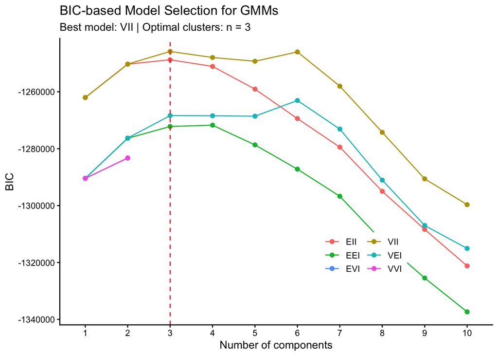

```r
fviz_mclust(gmm_res, "BIC") +
  labs(title = "BIC-based Model Selection for GMMs")
```

```r
table(NCI60$labs, gmm_res$classification)
```

```
              1 2 3
  BREAST      3 2 2
  CNS         5 0 0
  COLON       0 7 0
  K562A-repro 0 1 0
  K562B-repro 0 1 0
  LEUKEMIA    0 6 0
  MCF7A-repro 0 1 0
  MCF7D-repro 0 1 0
  MELANOMA    1 0 7
  NSCLC       8 1 0
  OVARIAN     6 0 0
  PROSTATE    2 0 0
  RENAL       9 0 0
  UNKNOWN     1 0 0
```

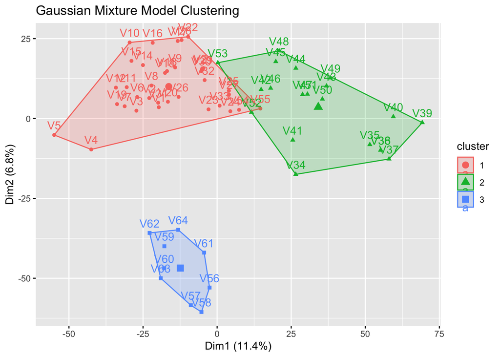

```r
fviz_cluster(list(data = X.scaled, cluster = gmm_res$classification)) +
  labs(title = "Gaussian Mixture Model Clustering")
```

# 7 Hierarchical Clustering

## 7.1 1. Compute Dissimilarity Matrix

```r
d <- dist(X.scaled, method = "euclidean")
hc_complete <- hclust(d, method = "complete")
hc_average  <- hclust(d, method = "average")
hc_single   <- hclust(d, method = "single")
```

## 7.2 2. Dendrograms

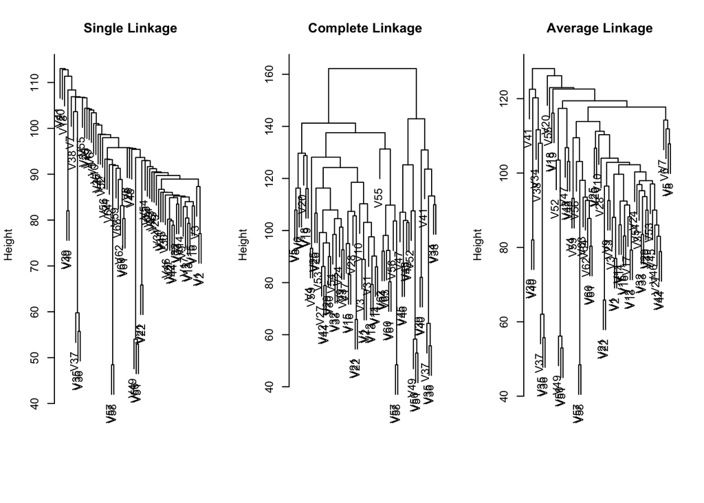

```r
par(mfrow = c(1,3))
plot(hc_single, main = "Single Linkage", xlab = "", sub = "")
plot(hc_complete, main = "Complete Linkage", xlab = "", sub = "")
plot(hc_average, main = "Average Linkage", xlab = "", sub = "")
```

## 7.3 3. Cut Tree and Visualize

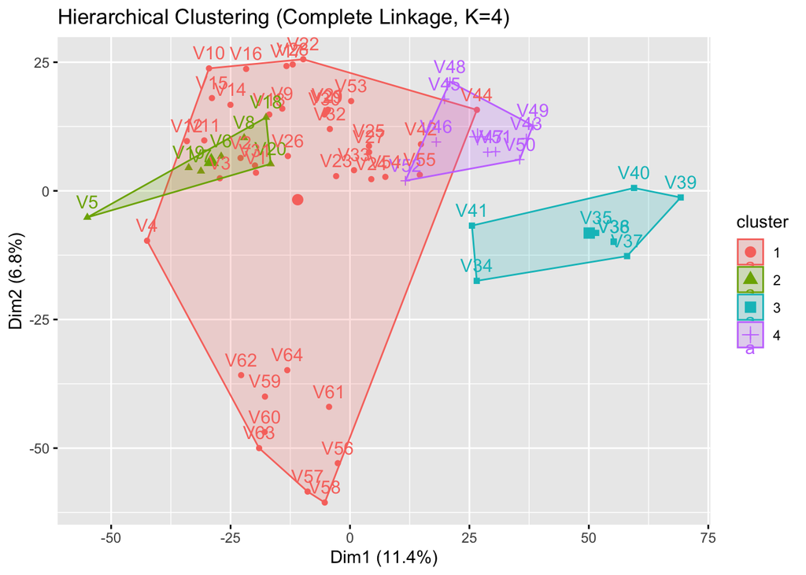

```r
cut_complete <- cutree(hc_complete, k = 4)
fviz_cluster(list(data = X.scaled, cluster = cut_complete)) +
  labs(title = "Hierarchical Clustering (Complete Linkage, K=4)")
```

```r
table(NCI60$labs,cut_complete)
```

```
             cut_complete
              1 2 3 4
  BREAST      2 3 0 2
  CNS         3 2 0 0
  COLON       2 0 0 5
  K562A-repro 0 0 1 0
  K562B-repro 0 0 1 0
  LEUKEMIA    0 0 6 0
  MCF7A-repro 0 0 0 1
  MCF7D-repro 0 0 0 1
  MELANOMA    8 0 0 0
  NSCLC       8 1 0 0
  OVARIAN     6 0 0 0
  PROSTATE    2 0 0 0
  RENAL       8 1 0 0
  UNKNOWN     1 0 0 0
```

# 8 Clustering t-SNE and UMAP Scores

t-SNE and UMAP (see the Dimension Reduction notes) compress the 6,830 genes into 2 coordinates that preserve *local* neighborhoods. A common workflow is to cluster those 2-D scores, since in two dimensions the clusters are easy to see and the distance calculations are cheap.

Two cautions:

- With only $n = 64$ cell lines, the t-SNE perplexity must be small (it has to be less than $(n-1)/3 \approx 21$), and UMAP needs a small `n_neighbors`.
- t-SNE and UMAP do not preserve global distances, so the size of, and gaps between, clusters in the embedding should not be over-interpreted. Both are also stochastic: different seeds give different embeddings. Because of this we judge any clustering of the scores by the original data (see the comparison section below), not just by how the 2-D picture looks.

## 8.1 Compute the Embeddings

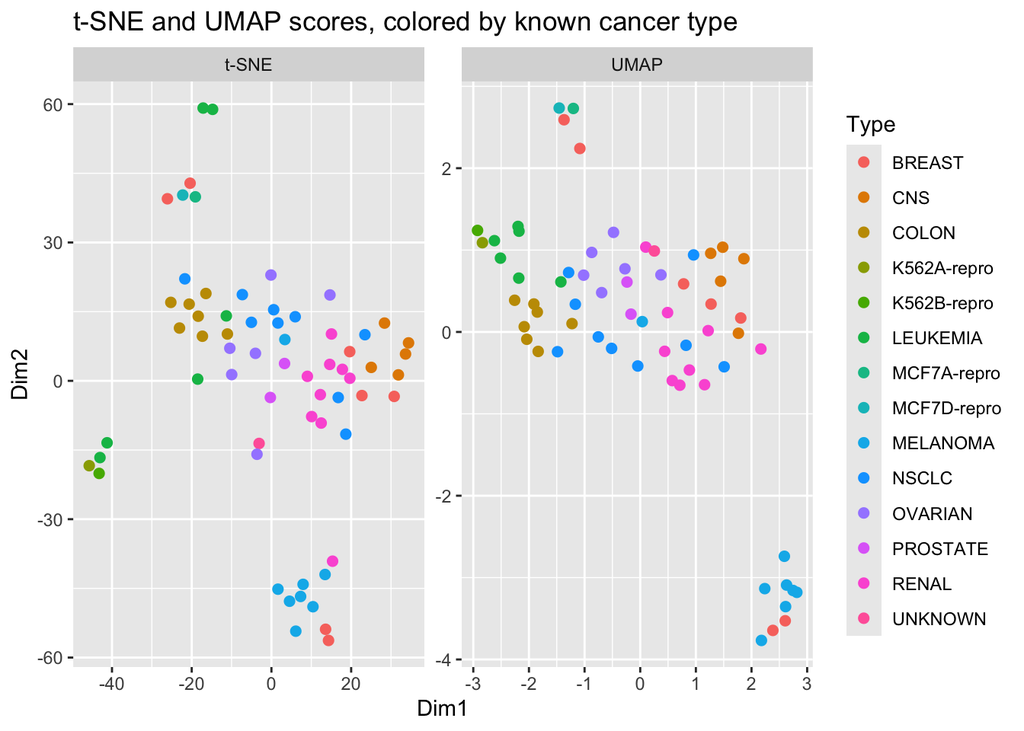

```r
set.seed(123)
tsne_fit <- Rtsne(X.scaled, dims = 2, perplexity = 5, check_duplicates = FALSE)
tsne_scores <- tsne_fit$Y

set.seed(123)
umap_scores <- umap(X.scaled, n_neighbors = 10, min_dist = 0.1)

emb <- bind_rows(
  tibble(Dim1 = tsne_scores[, 1], Dim2 = tsne_scores[, 2], Method = "t-SNE", Type = NCI60$labs),
  tibble(Dim1 = umap_scores[, 1], Dim2 = umap_scores[, 2], Method = "UMAP",  Type = NCI60$labs)
)
ggplot(emb, aes(Dim1, Dim2, color = Type)) +
  geom_point(size = 2) +
  facet_wrap(~Method, scales = "free") +
  labs(title = "t-SNE and UMAP scores, colored by known cancer type")
```

## 8.2 K-means and GMM on the Scores

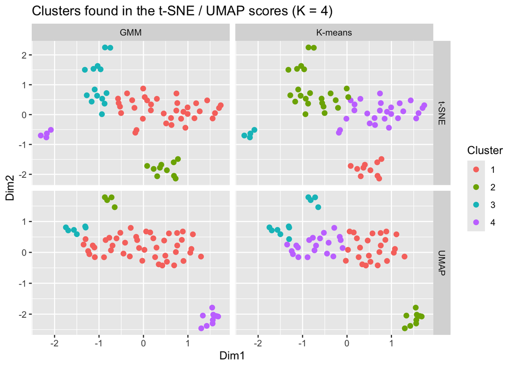

```r
set.seed(123)
km_tsne  <- kmeans(tsne_scores, centers = 4, nstart = 25)
km_umap  <- kmeans(umap_scores, centers = 4, nstart = 25)
gmm_tsne <- Mclust(tsne_scores, G = 4, verbose = FALSE)
gmm_umap <- Mclust(umap_scores, G = 4, verbose = FALSE)

score_clusters <- bind_rows(
  tibble(Dim1 = scale(tsne_scores[, 1]), Dim2 = scale(tsne_scores[, 2]), Method = "t-SNE", Clustering = "K-means", Cluster = km_tsne$cluster),
  tibble(Dim1 = scale(tsne_scores[, 1]), Dim2 = scale(tsne_scores[, 2]), Method = "t-SNE", Clustering = "GMM",     Cluster = gmm_tsne$classification),
  tibble(Dim1 = scale(umap_scores[, 1]), Dim2 = scale(umap_scores[, 2]), Method = "UMAP",  Clustering = "K-means", Cluster = km_umap$cluster),
  tibble(Dim1 = scale(umap_scores[, 1]), Dim2 = scale(umap_scores[, 2]), Method = "UMAP",  Clustering = "GMM",     Cluster = gmm_umap$classification)
)
ggplot(score_clusters, aes(Dim1, Dim2, color = factor(Cluster))) +
  geom_point(size = 2) +
  facet_grid(Method ~ Clustering, scales = "free") +
  labs(color = "Cluster", title = "Clusters found in the t-SNE / UMAP scores (K = 4)")
```

Compare the clusters to the known cancer types:

```r
table(NCI60$labs, km_umap$cluster)
```

```
              1 2 3 4
  BREAST      3 2 2 0
  CNS         5 0 0 0
  COLON       0 0 0 7
  K562A-repro 0 0 1 0
  K562B-repro 0 0 1 0
  LEUKEMIA    0 0 5 1
  MCF7A-repro 0 0 1 0
  MCF7D-repro 0 0 1 0
  MELANOMA    1 7 0 0
  NSCLC       4 0 0 5
  OVARIAN     1 0 0 5
  PROSTATE    0 0 0 2
  RENAL       9 0 0 0
  UNKNOWN     1 0 0 0
```

### 8.2.1 Choosing K in the embedding

The same tools apply to the scores. Here we use the silhouette width and the GMM BIC on the UMAP scores.

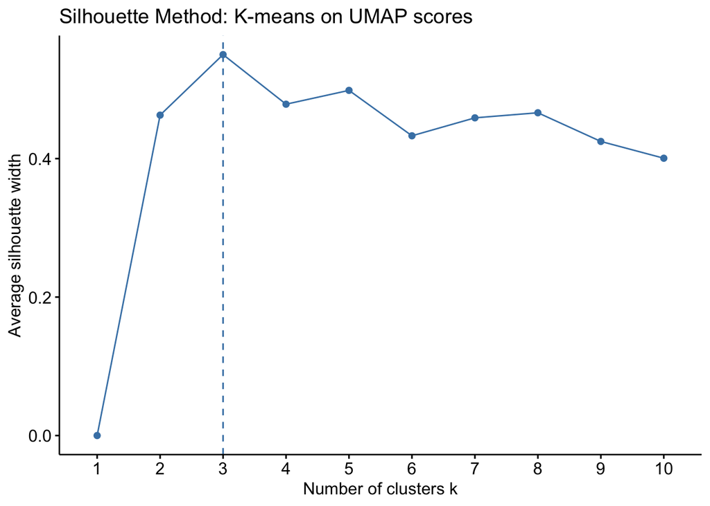

```r
fviz_nbclust(umap_scores, kmeans, method = "silhouette") +
  labs(title = "Silhouette Method: K-means on UMAP scores")
```

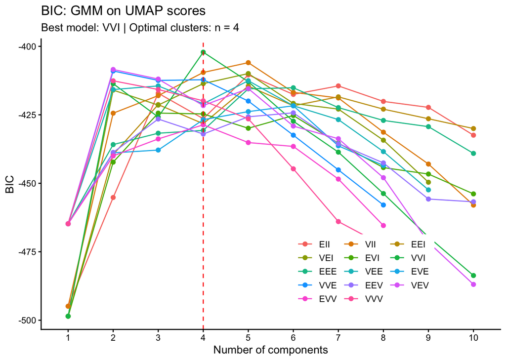

```r
fviz_mclust(Mclust(umap_scores, G = 1:10, verbose = FALSE), "BIC") +
  labs(title = "BIC: GMM on UMAP scores")
```

# 9 Comparing Methods

Different clustering methods will always return *some* partition, so we need a principled way to say which is better. There are three complementary views:

1. **Internal validation** uses only the data: are clusters compact and well separated?
2. **External validation** uses known labels (here, the 14 cancer types) as a benchmark. This is a luxury: in real applications there is usually no truth, but it is a useful check on a teaching dataset.
3. **Stability**: would we get the same clusters with a different random seed?

## 9.1 Measures

**Internal.**

- *Average silhouette width* (defined above).
- *Calinski–Harabasz index*: ratio of between-cluster to within-cluster variance (adjusted for $K$ and $n$); larger is better.
- *Dunn index*: smallest between-cluster distance divided by largest cluster diameter; larger is better, but very sensitive to a single outlier.

**External.**

- *Adjusted Rand Index (ARI)*: the fraction of pairs of observations on which two partitions agree (both together or both apart), corrected for chance. ARI = 1 is perfect agreement and ARI $\approx$ 0 is what random labels give.
- *Normalized Mutual Information (NMI)*: how much knowing the cluster tells you about the cancer type, scaled to [0, 1].
- *Purity*: the share of observations that belong to the majority cancer type of their cluster. Purity is easy to read, but it can be inflated by using more clusters.

**Important**

All internal measures below are computed in the **original standardized gene space** for every method. If we computed the silhouette of the UMAP clusters in the UMAP space, it would look artificially good, because UMAP is designed to pull points together.

```r
nmi <- function(a, b) {
  tab <- table(a, b); p <- tab / sum(tab)
  pa <- rowSums(p); pb <- colSums(p)
  mi <- sum(p[p > 0] * log(p[p > 0] / outer(pa, pb)[p > 0]))
  ha <- -sum(pa[pa > 0] * log(pa[pa > 0])); hb <- -sum(pb[pb > 0] * log(pb[pb > 0]))
  mi / sqrt(ha * hb)
}
purity <- function(cl, truth) sum(apply(table(cl, truth), 1, max)) / length(cl)

d_orig <- dist(X.scaled)

evaluate <- function(cl, truth = NCI60$labs, d = d_orig) {
  st <- fpc::cluster.stats(d, as.integer(factor(cl)))
  tibble(
    Silhouette = st$avg.silwidth,
    CH         = st$ch,
    Dunn       = st$dunn,
    ARI        = adjustedRandIndex(cl, truth),
    NMI        = nmi(cl, truth),
    Purity     = purity(cl, truth)
  )
}
```

## 9.2 All Methods at K = 4

```r
partitions <- list(
  "K-means (genes)"      = km_res$cluster,
  "PAM (genes)"          = pam_res$clustering,
  "GMM (genes, BIC)"     = gmm_res$classification,
  "Hier. complete"       = cut_complete,
  "Hier. average"        = cutree(hc_average, k = 4),
  "Hier. Ward"           = cutree(hclust(d, method = "ward.D2"), k = 4),
  "K-means (t-SNE)"      = km_tsne$cluster,
  "GMM (t-SNE)"          = gmm_tsne$classification,
  "K-means (UMAP)"       = km_umap$cluster,
  "GMM (UMAP)"           = gmm_umap$classification
)

results <- bind_rows(lapply(partitions, evaluate), .id = "Method") |>
  mutate(K = sapply(partitions, function(x) length(unique(x))))
results |>
  arrange(desc(ARI)) |>
  mutate(across(where(is.numeric) & !K, ~ round(.x, 3))) |>
  kable()
```

| Method | Silhouette | CH | Dunn | ARI | NMI | Purity | K |
| --- | --- | --- | --- | --- | --- | --- | --- |
| K-means (UMAP) | 0.066 | 4.563 | 0.596 | 0.249 | 0.547 | 0.438 | 4 |
| K-means (genes) | 0.080 | 4.976 | 0.612 | 0.221 | 0.529 | 0.453 | 4 |
| Hier. Ward | 0.076 | 4.797 | 0.601 | 0.195 | 0.536 | 0.438 | 4 |
| GMM (genes, BIC) | 0.077 | 5.257 | 0.559 | 0.181 | 0.498 | 0.359 | 3 |
| K-means (t-SNE) | 0.077 | 4.512 | 0.570 | 0.157 | 0.454 | 0.375 | 4 |
| GMM (t-SNE) | 0.081 | 4.477 | 0.551 | 0.140 | 0.440 | 0.359 | 4 |
| Hier. complete | 0.070 | 4.045 | 0.583 | 0.127 | 0.463 | 0.344 | 4 |
| PAM (genes) | 0.081 | 4.481 | 0.551 | 0.117 | 0.437 | 0.359 | 4 |
| GMM (UMAP) | 0.089 | 4.503 | 0.633 | 0.110 | 0.470 | 0.344 | 4 |
| Hier. average | 0.079 | 2.702 | 0.709 | 0.050 | 0.387 | 0.250 | 4 |

Note that the GMM on the genes used the K chosen by BIC rather than K = 4 (see the `K` column).

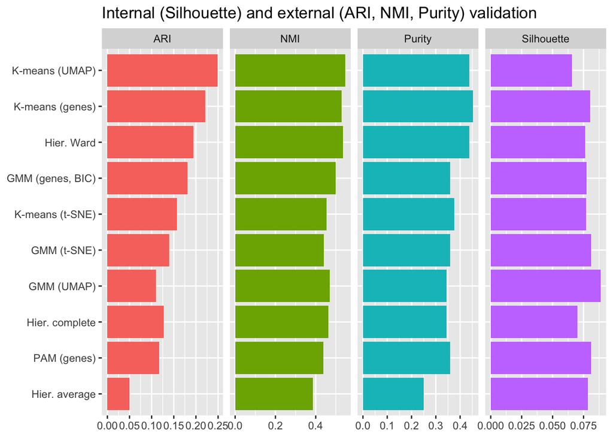

```r
results |>
  select(Method, Silhouette, ARI, NMI, Purity) |>
  pivot_longer(-Method, names_to = "Measure") |>
  ggplot(aes(value, reorder(Method, value), fill = Measure)) +
  geom_col(show.legend = FALSE) +
  facet_wrap(~Measure, scales = "free_x", nrow = 1) +
  labs(x = NULL, y = NULL, title = "Internal (Silhouette) and external (ARI, NMI, Purity) validation")
```

How the partitions agree with each other (pairwise ARI):

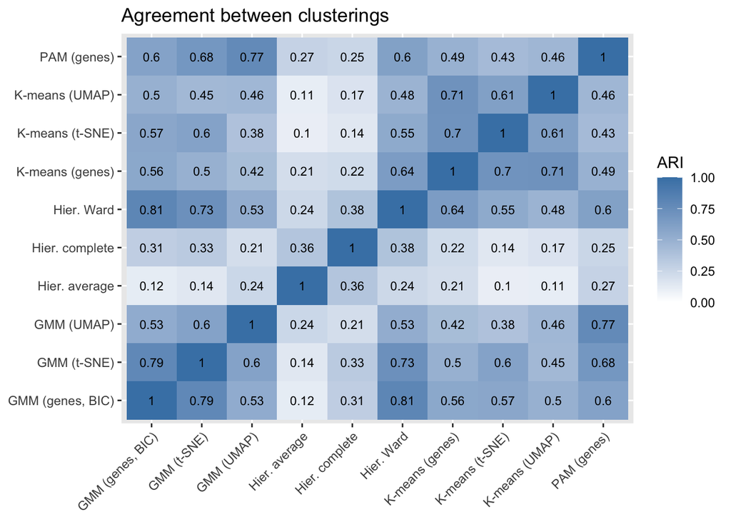

```r
ari_mat <- outer(seq_along(partitions), seq_along(partitions),
                 Vectorize(function(i, j) adjustedRandIndex(partitions[[i]], partitions[[j]])))
dimnames(ari_mat) <- list(names(partitions), names(partitions))
as_tibble(ari_mat, rownames = "A") |>
  pivot_longer(-A, names_to = "B", values_to = "ARI") |>
  ggplot(aes(A, B, fill = ARI)) +
  geom_tile() +
  geom_text(aes(label = round(ARI, 2)), size = 3) +
  scale_fill_gradient(low = "white", high = "steelblue", limits = c(0, 1)) +
  theme(axis.text.x = element_text(angle = 45, hjust = 1)) +
  labs(x = NULL, y = NULL, title = "Agreement between clusterings")
```

## 9.3 Sensitivity to K

The best method at K = 4 may not be the best at K = 8. We sweep K for the methods that let us set it directly.

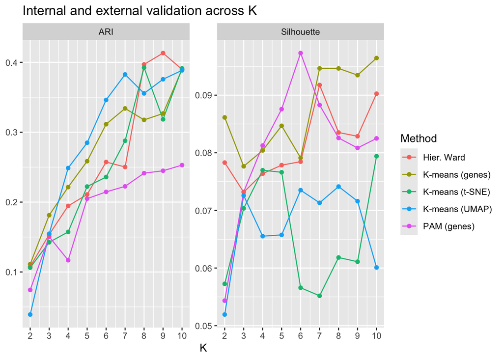

```r
run_k <- function(k) {
  set.seed(k)
  list(
    "K-means (genes)" = kmeans(X.scaled, k, nstart = 25)$cluster,
    "PAM (genes)"     = pam(X.scaled, k)$clustering,
    "Hier. Ward"      = cutree(hclust(d, method = "ward.D2"), k),
    "K-means (t-SNE)" = kmeans(tsne_scores, k, nstart = 25)$cluster,
    "K-means (UMAP)"  = kmeans(umap_scores, k, nstart = 25)$cluster
  )
}
sweep <- map_dfr(2:10, function(k) {
  parts <- run_k(k)
  bind_rows(lapply(parts, evaluate), .id = "Method") |> mutate(K = k)
})
sweep |>
  select(Method, K, Silhouette, ARI) |>
  pivot_longer(c(Silhouette, ARI), names_to = "Measure") |>
  ggplot(aes(K, value, color = Method)) +
  geom_line() + geom_point() +
  facet_wrap(~Measure, scales = "free_y") +
  scale_x_continuous(breaks = 2:10) +
  labs(y = NULL, title = "Internal and external validation across K")
```

## 9.4 Stability

t-SNE, UMAP, and K-means all depend on random starts. A method whose answer changes substantially from seed to seed is hard to trust. We refit each pipeline (embedding + clustering) with 20 different seeds and record the ARI against the cancer types.

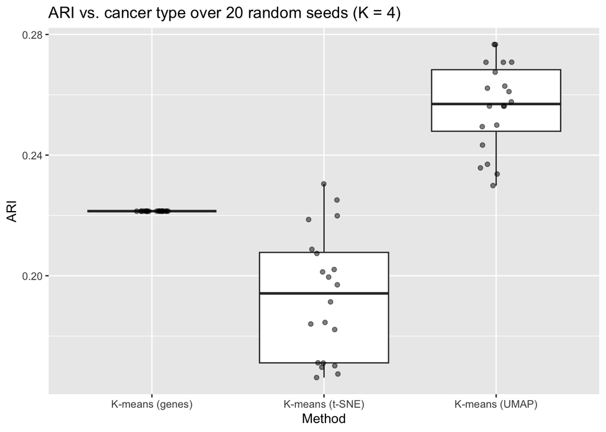

```r
stab <- map_dfr(1:20, function(s) {
  set.seed(s)
  ts <- Rtsne(X.scaled, perplexity = 10, check_duplicates = FALSE)$Y
  um <- umap(X.scaled, n_neighbors = 10, min_dist = 0.1)
  tibble(
    Seed = s,
    "K-means (genes)" = adjustedRandIndex(kmeans(X.scaled, 4, nstart = 25)$cluster, NCI60$labs),
    "K-means (t-SNE)" = adjustedRandIndex(kmeans(ts, 4, nstart = 25)$cluster, NCI60$labs),
    "K-means (UMAP)"  = adjustedRandIndex(kmeans(um, 4, nstart = 25)$cluster, NCI60$labs)
  )
}) |> pivot_longer(-Seed, names_to = "Method", values_to = "ARI")

ggplot(stab, aes(Method, ARI)) +
  geom_boxplot(outlier.shape = NA) +
  geom_jitter(width = 0.1, alpha = 0.5) +
  labs(title = "ARI vs. cancer type over 20 random seeds (K = 4)")
```

```r
stab |> group_by(Method) |> summarise(mean = mean(ARI), sd = sd(ARI)) |> kable(digits = 3)
```

| Method | mean | sd |
| --- | --- | --- |
| K-means (UMAP) | 0.256 | 0.014 |
| K-means (genes) | 0.221 | 0.000 |
| K-means (t-SNE) | 0.193 | 0.021 |

# 10 Summary

- **K-means** Fast, easy to interpret, but sensitive to scaling, outliers
- **PAM** Robust to outliers, but slower on large datasets.
- **GMM** Captures overlapping/elliptical clusters, but requires distributional assumptions.
- **Hierarchical** Dendrogram visualization, no K needed a priori, but is computationally intensive.
- **Clustering t-SNE/UMAP scores** Easy to visualize and often separates groups well, but distances in the embedding are distorted and results vary with the seed and tuning parameters (perplexity, `n_neighbors`); validate in the original space.